# snapper快照管理工具

2020-06-21 00:14:18

## 配置文件

Snapper 需要为每一个卷创建一个配置文件，配置文件定义了快照的创建和维护规则。 Snapper 的每一个操作都是根据卷对应的配置文件进行的。

### 创建配置文件

```
snapper -c <配置名称> create-config <子卷路径>
snapper -c lvm_config create-config -f “lvm(ext4)” /lvm_mount
```

### 配置文件模板

`/etc/snapper/config-templates/default`

### 列出所有的配置文件

```
snapper list-configs
```

### 配置文件参数

TIMELINE_CREATE :如果设置为yes，便会每小时创建一个快照。这是目前唯一一种可以自动创建快照的方式，因此强烈建议将其设置为 yes。

ALLOW_USERS 和（或）ALLOW_GROUPS：分别为用户和（或）组授予权限。多个条目需要使用空格 分隔。例如，要为用户 thin_user 和 thin_group 授予权限，可运行：

```
snapper -c web_data set-config “ALLOW_USERS=thin_user” “ALLOW_GROUPS=thin_group”
```

## 使用快照

### 文件位置

Snapper 的快照数据存储在当前子卷根目录的 .snapshots 隐藏文件夹中 `/mnt/test/.snapshots`

### 快照种类

- Pre Snapshot：修改前的文件系统快照。每一张前快照都有一个对应的post快照。
- Post Snapshot：修改后的文件系统快照。每一张后快照都有一个对应的pre快照。
- Single Snapshot：独立的快照。目的之一就是为了自动创建每小时快照。此为创建快照时的默认类型。

### 创建快照

```
snapper -c config_name create -t pre -p (打印编号)
snapper -c config_name create -t post -p
snapper -c btrfs_config create --command "yum install net-tools"
# 实现三步操作（1.pre 2.yum 3.post） 在测试中很实用
snapper -c lvm_config create [-t single ]
```

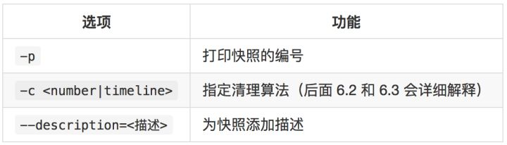

### 查看快照

```
# snapper -c test_con list
```

### 比对快照的差异

```
snapper -c lvm_config status 3..4
snapper -c test_con diff 10..11 /mnt/test/wwww
snapper -c test_con xadiff 30..31
```

第一列 “+”号代表新增文件，“-”代表删除文件，“c”代表修改了文件，. 什么都没变，”t” 文件属性变了，例如链接之类的。与diff语法相同。 第二列 权限的改变 .没改 p改了 第三列 用户 第四列 组 第五列 extended attributes 第六列 acl

### 删除快照

```
snapper -c snap_test delete 1
```

### 回滚快照

```
snapper -c <配置名称> undochange <快照编号>..<0>
snapper -c config_name undochange 1..2 取消1到2的更改
```

## 快照的自动拍摄与清理

### 开启快照自动拍摄

```
systemctl start snapper-timeline.timer ; systemctl enable snapper-timeline.timer
```

默认情况下，每小时自动拍摄一次快照。

如需修改时间间隔，请修改相关的定时器配置文件。

快照的清理算法将被自动设定为 `timeline`

### 开启快照自动清理

```
systemctl start snapper-cleanup.timer ; systemctl enable snapper-cleanup.timer
```

默认情况下，每天自动清理一次快照。

如需修改时间间隔，请修改相关的定时器配置文件。修改方法这里就不说了。

不指定清理算法的快照不会被自动清理。

### 修改快照自动清理的参数

配置文件位置：`/etc/snapper/configs/<配置名称>`

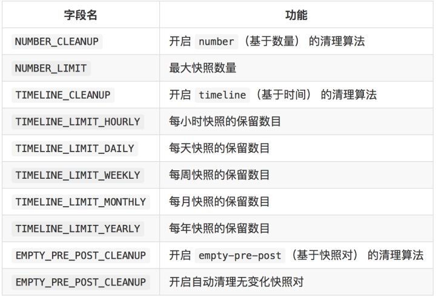

文件系统创建： mkfs.btrfs -L ‘LABEL’ -d : raid0, raid1, raid5, raid6, raid10, single -m : raid0, raid1, raid5, raid6, raid10, single, dup -O -O list-all: 列出支持的所有feature；

属性查看： btrfs filesystem show

挂载文件系统： mount -t btrfs /dev/sdb MOUNT_POINT

透明压缩机制（拷贝过来一个文件查看大小也完全一样，这个压缩内部理论有待研究）： mount -o compress={lzo|zlib} DEVICE MOUNT_POINT

缩小文件系统（我在测试的时候，两个20G的硬盘，我仅仅只能减去17G，再多就报错了）： btrfs filesystem resize -13G /mydata 扩容文件系统： btrfs filesystem resize +13G /mydata 或者（扩充到最大） btrfs filesystem resize max /mydata

添加一个硬盘： btrfs device add /dev/sdd /mydata

把/mydata中其它的数据，均衡（移动到）到新添加的磁盘中（会占用io资源）： btrfs balance start /mydata btrfs balance status #查看状态 注意：如果数据量过大的时候，这个时间可能就会很久 balance也有暂停（pause），继续（resume），取消（cancel）等操作，可以通过man btrfs-balance去查看下

移除一个物理卷（btrfs会自动把数据先挪走再拆除）： btrfs device delete /dev/sdb /mydata

修改raid级别（有点晕，需要查一下这几个组织机制的关系） 修改数据的组织机制：act on data chunks btrfs balance -dconvert=raid0 /mydata 修改元数据的组织机制：act on metadata chunks btrfs balance -mconvert=raid1 /mydata 修改系统的组织机制：act on system chunks btrfs balance -sconvert=raid5 /mydata

btrfs的子命令： filesystem device balance subvolume #子卷的管理命令

创建一个子卷cache： btrfs subvolume create /mydata/cache 挂在子卷 mount -o subvol=cache /dev/sdb /mnt 也可以使用subid挂载 mount -o subvolid=268 /dev/sdb /mnt 查看volid： btrfs subvolume list /mydata

删除子卷（注意：请先挂在父卷）： btrfs subvolume dalete /mydata/cache

创建快照(快照卷必须与原卷在同一个卷组中)： btrfs subvolume snapshot /mydata/logs /mydata/logs_snapshot 删除快照： btrfs subvolume dalete /mydata/logs_snapshot 对单个文件创建快照： cp –reflink file.txt file.txt_snapshot 把其它文件系统转换成btrfs（这里拿ext4做的测试，其它文件系统请一定要事前严格测试下）： 强制检测下： fsck -f /dev/sdd1 转换(数据没丢): btrfs-convert /dev/sdd1 查看有没有生效： btrfs filesystem show 回滚到之前的文件系统（之前是ext4）： btrfs-convert -r /dev/sdd1 查看： blkid /dev/sdd1